# Análise Candidaturas

## Candidatos por gênero

Os gráficos a seguir expressam a combinação entre diversas variáveis com o gênero dos candidatos.

### Em Roraima

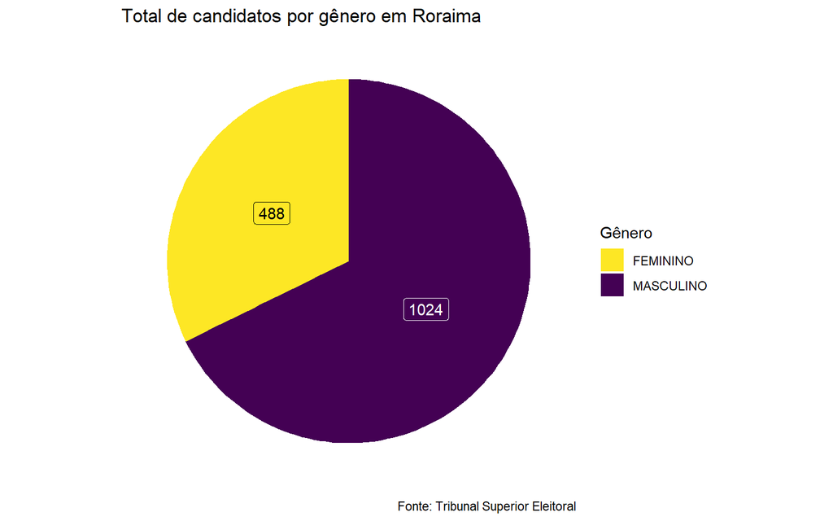

Na eleições de 2016 para vereador, Roraima teve 1024 candidatos e 488 candidatas.

### Por município

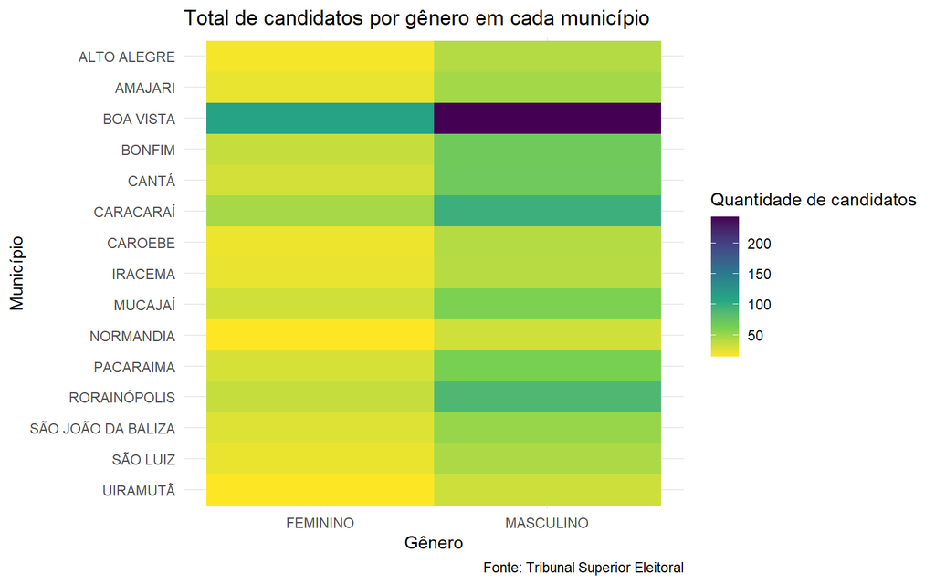

Observa-se que, em geral, há mais homens candidatos nos municípios do que mulheres.

### Porcentagem de candidatos por gênero em cada município

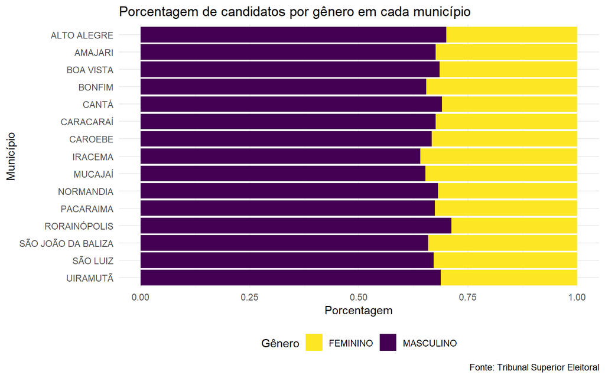

Com o gráfico de percentual, é possível notar como os homens são a maiora dos candidatos a vereador nas eleições municipais de Roraima.

### Taxa de sucesso de candidatas

Entre o total de candidatas, são poucas as mulheres eleitas como podemos ver no gráfico abaixo.

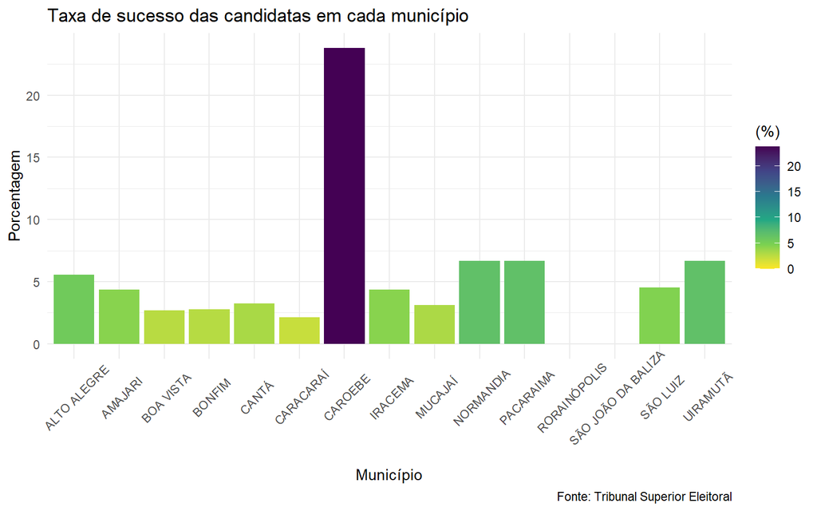

### Taxa de sucesso de candidatos de ambos os gêneros

No geral, a taxa de sucesso dos candidatos homens a vereador é maior do que a de mulheres como pode-se observar no gráfico abaixo.

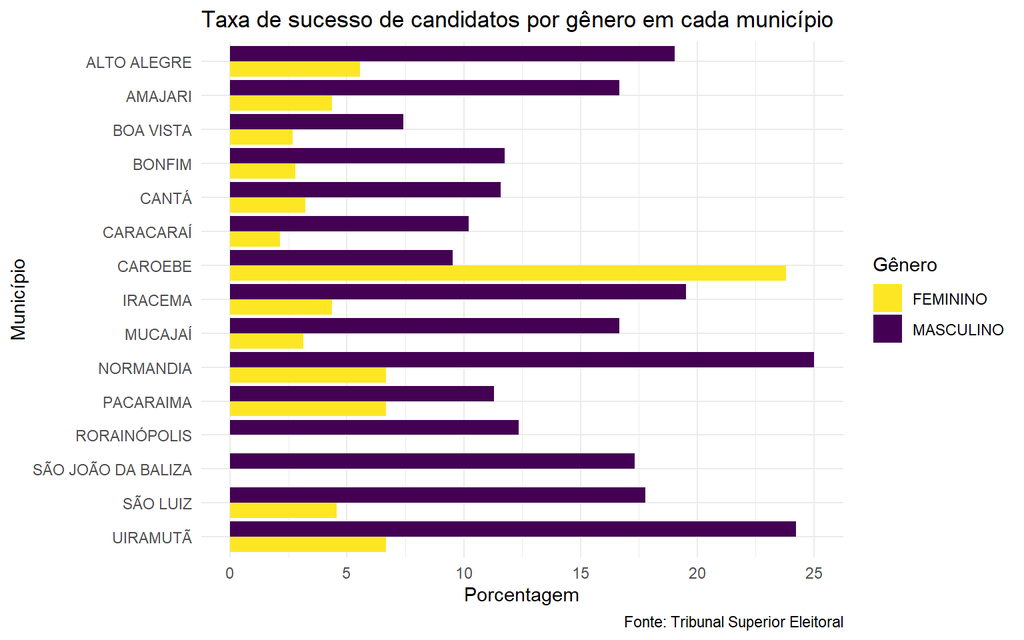

A partir dos gráficos também nota-se que o município de Caroebe é aquele em que as mulheres têm maior taxa de sucesso do que os homens.

## Candidatos por idade

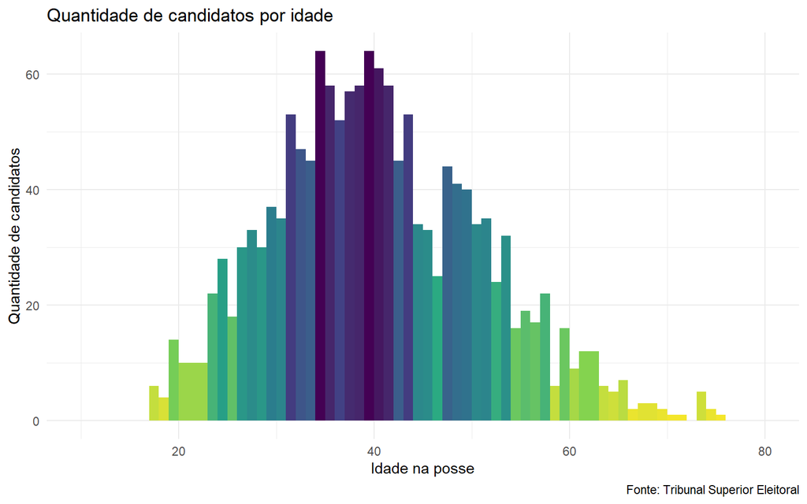

Pelo gráfico nota-se que a maior parte dos candidatos tinha em torno de 40 anos no dia da posse.

### por gênero

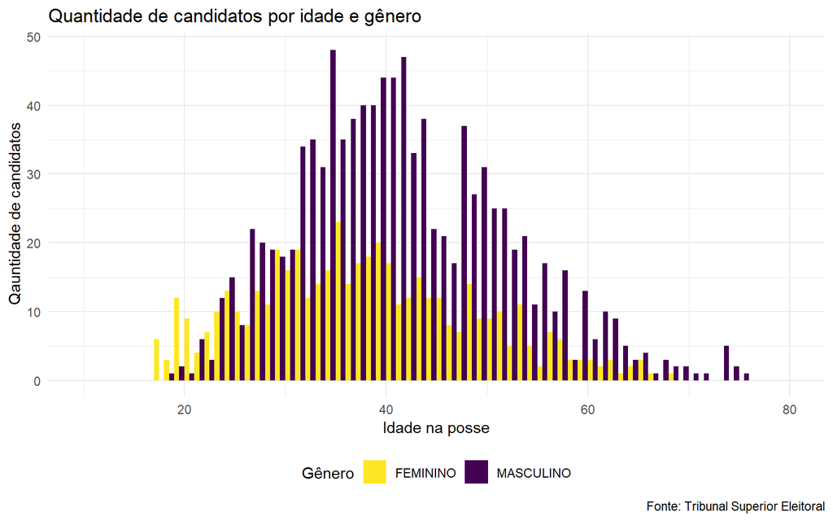

As candidatas mulheres tendem a ser mais jovens. Os homens predominam entre os candidatos acima dos 30 anos.

### por gênero e cor

No gráfico abaixo é possível observar a relação entre idade, gênero e cor dos candidatos a vereador das eleições municipais de Roraima em 2016.

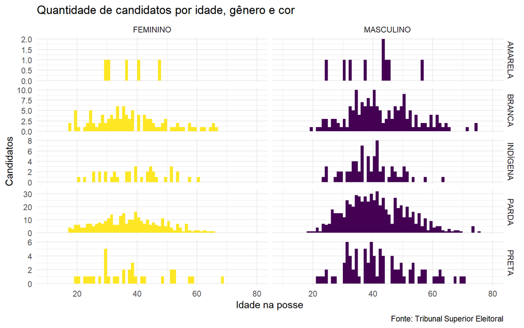

Note ainda que no gráfico a quantidade de candidatos é variável para cada cor. Esta escolha foi feita para melhor observar os dados.

## Resultados das eleições

Os gráficos a seguir mostram a relacão entre porcentagem média de votos dos candidatos numa determinada idade.

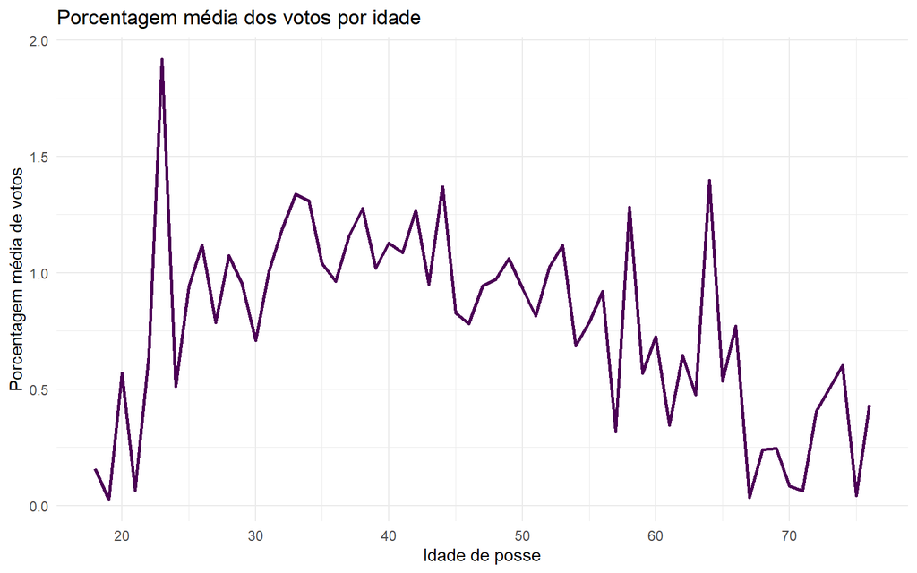

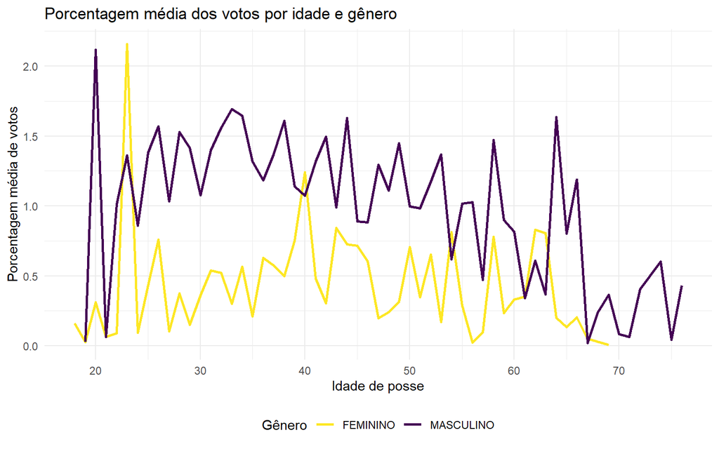

## Índice de Desenvolvimento Humano

O gráfico a seguir oferecem diferentes formas de observar a relação entre a porcentagem de votos no PMDB e o IDH do município.

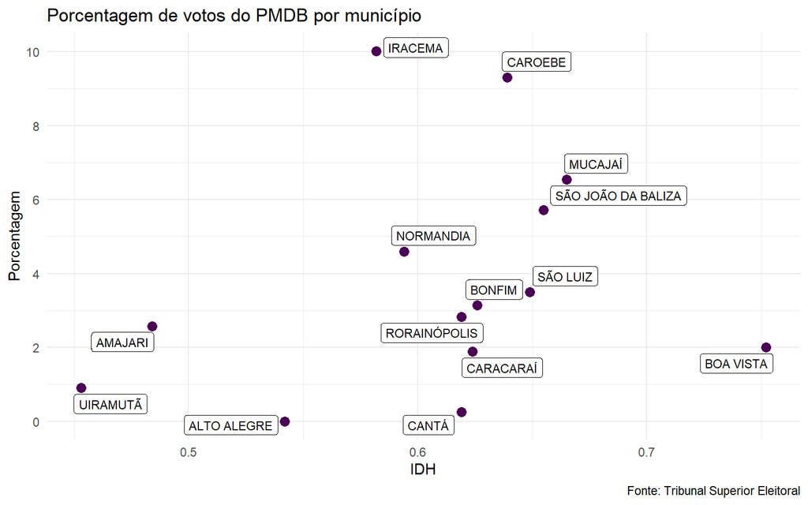

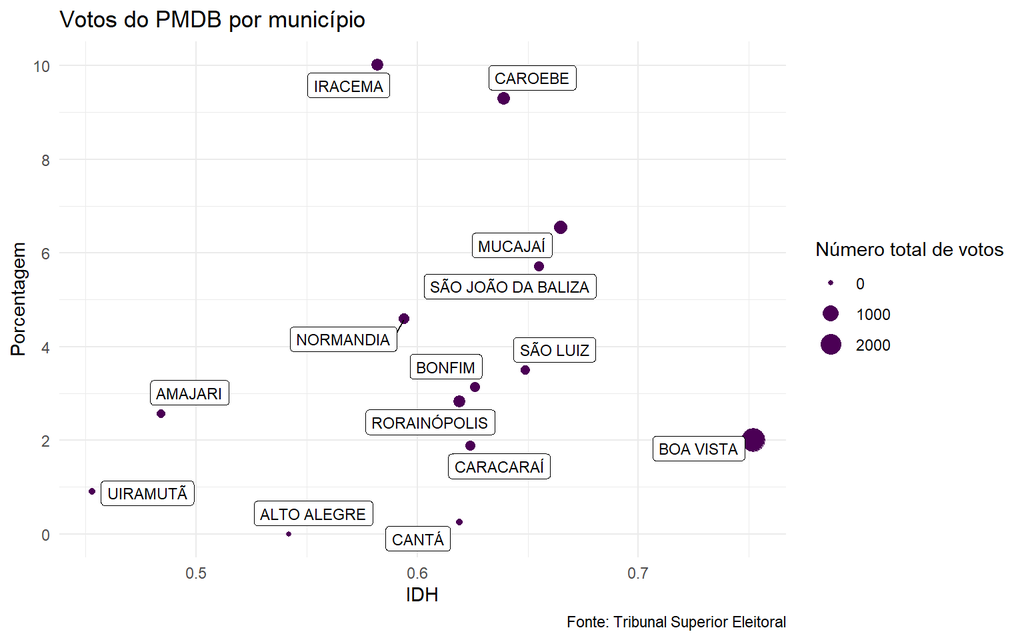

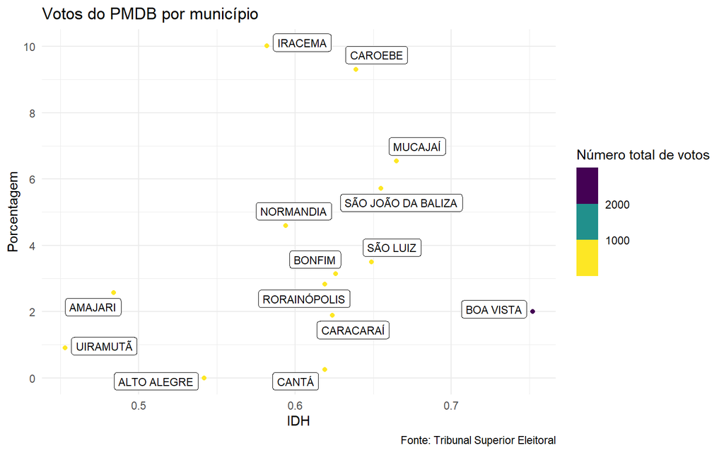